# hw2_code

### Footbal Match Result Prediction

```python
import numpy as np
import pandas as pd
import matplotlib.pyplot as plt
import seaborn as sns
from sklearn.decomposition import PCA
from sklearn.linear_model import LinearRegression
from sklearn.model_selection import train_test_split
from sklearn.metrics import mean_squared_error, r2_score
from sklearn.preprocessing import StandardScaler
import matplotlib.pyplot as plt
```

```python
match_data = pd.read_csv('match_data', delimiter=',')  # Change delimiter if necessary

print(match_data.columns)
```

```
Index(['fixture_id', 'halftime', 'current_time', 'half_start_datetime',
       'match_start_datetime', 'minute', 'second', 'latest_bookmaker_update',
       'suspended', 'stopped',
       ...
       'Throwins - home', 'Total Crosses - away', 'Total Crosses - home',
       'Yellowcards - away', 'Yellowcards - home', 'Yellowred Cards - away',
       'Yellowred Cards - home', 'current_state', 'final_score', 'result'],
      dtype='object', length=106)
```

```python
match_data.head()
```

|  | fixture_id | halftime | current_time | half_start_datetime | match_start_datetime | minute | second | latest_bookmaker_update | suspended | stopped | ... | Throwins - home | Total Crosses - away | Total Crosses - home | Yellowcards - away | Yellowcards - home | Yellowred Cards - away | Yellowred Cards - home | current_state | final_score | result |
| --- | --- | --- | --- | --- | --- | --- | --- | --- | --- | --- | --- | --- | --- | --- | --- | --- | --- | --- | --- | --- | --- |
| 0 | 19172016.0 | 1st-half | 2024-08-09 18:11:36 | 2024-08-09 18:01:37 | 2024-08-09 18:01:37 | 9 | 59 | 2024-08-09 18:11:28 | False | False | ... | 1.0 | 0.0 | 3.0 | 0.0 | 0.0 | 0.0 | 0.0 | X | 2-1 | 1 |
| 1 | 19172016.0 | 1st-half | 2024-08-09 18:27:30 | 2024-08-09 18:01:37 | 2024-08-09 18:01:37 | 25 | 53 | 2024-08-09 18:27:24 | False | False | ... | 11.0 | 1.0 | 12.0 | 0.0 | 0.0 | 0.0 | 0.0 | X | 2-1 | 1 |
| 2 | 19172016.0 | 1st-half | 2024-08-09 18:28:25 | 2024-08-09 18:01:37 | 2024-08-09 18:01:37 | 26 | 48 | 2024-08-09 18:28:20 | False | False | ... | 11.0 | 1.0 | 13.0 | 0.0 | 0.0 | 0.0 | 0.0 | X | 2-1 | 1 |
| 3 | 19172016.0 | 1st-half | 2024-08-09 18:29:32 | 2024-08-09 18:01:37 | 2024-08-09 18:01:37 | 27 | 55 | 2024-08-09 18:29:28 | False | False | ... | 11.0 | 1.0 | 13.0 | 0.0 | 0.0 | 0.0 | 0.0 | X | 2-1 | 1 |
| 4 | 19172016.0 | 1st-half | 2024-08-09 18:30:37 | 2024-08-09 18:01:37 | 2024-08-09 18:01:37 | 29 | 0 | 2024-08-09 18:30:32 | True | False | ... | 11.0 | 1.0 | 14.0 | 0.0 | 0.0 | 0.0 | 0.0 | X | 2-1 | 1 |

5 rows × 106 columns

#### Data Preprocessing

Suspended and stopped matches are removed from the data and missing values are handled my taking the mean of other available rows corresponding to the same match(fixture_id) due to high missing value rate. After filling NAs with the mean, some missing values still exist, so their values taken as zero. 38 rows do not have current state column, there are excluded from the data.

```python
filtered_data = match_data[~(match_data['suspended'] | match_data['stopped'])]

missing_values = filtered_data.isnull().sum()
missing_values = missing_values[missing_values > 0]

print("Columns with Missing Values:")
print(missing_values)
```

```
Columns with Missing Values:
Accurate Crosses - away     2900
Accurate Crosses - home     2879
Assists - away             26239
Assists - home             26237
Attacks - away                38
                           ...
Yellowcards - away            78
Yellowcards - home            67
Yellowred Cards - away     21284
Yellowred Cards - home     21277
current_state                 38
Length: 85, dtype: int64
```

```python
filled_data = filtered_data.groupby('fixture_id').apply(
    lambda group: group.fillna(group.mean(numeric_only=True))
).reset_index(drop=True)

missing_values_2 = filled_data.isnull().sum()
print("Remaining Missing Values per Column:")
print(missing_values_2[missing_values_2 > 0])
```

```
Remaining Missing Values per Column:
Assists - away                 8909
Assists - home                 8909
Ball Safe - away               7211
Ball Safe - home               7211
Counter Attacks - away        28066
Counter Attacks - home        28066
Dribble Attempts - away          30
Dribble Attempts - home          30
Fouls - away                      6
Fouls - home                      6
Free Kicks - away             51070
Free Kicks - home             51070
Goal Attempts - away           8229
Goal Attempts - home           8229
Goal Kicks - away               560
Goal Kicks - home               560
Headers - away                 4262
Headers - home                 4262
Injuries - away               25464
Injuries - home               25464
Key Passes - away                 6
Key Passes - home                 6
Long Passes - away             2010
Long Passes - home             2010
Offsides - away                2823
Offsides - home                2823
Saves - away                    198
Saves - home                    198
Successful Dribbles - away        6
Successful Dribbles - home        6
Successful Headers - away      4262
Successful Headers - home      4262
Yellowred Cards - away         7128
Yellowred Cards - home         7128
current_state                    38
dtype: int64
```

```python
categorical_columns = filled_data.select_dtypes(include=['object', 'category']).columns
missing_categorical = filled_data[categorical_columns].isnull().sum()
missing_categorical
```

```
halftime                    0
current_time                0
half_start_datetime         0
match_start_datetime        0
latest_bookmaker_update     0
name                        0
current_state              38
final_score                 0
result                      0
dtype: int64
```

```python
filled_data = filled_data.dropna(subset=['current_state'])
filled_data = filled_data.fillna(0)
```

#### Part 1

```python
filled_data['P_home_win'] = 1 / filled_data['1']
filled_data['P_tie'] = 1 / filled_data['X']
filled_data['P_away_win'] = 1 / filled_data['2']

# Print the probabilities
print(filled_data[['P_home_win', 'P_tie', 'P_away_win']])
filled_data['P_sum'] = filled_data['P_home_win'] + filled_data['P_tie'] + filled_data['P_away_win']
filled_data['P_home_win_norm'] = filled_data['P_home_win']/filled_data['P_sum']
filled_data['P_tie_norm'] = filled_data['P_tie']/filled_data['P_sum']
filled_data['P_away_win_norm'] = filled_data['P_away_win']/filled_data['P_sum']

print(filled_data[['P_home_win_norm', 'P_tie_norm', 'P_away_win_norm']])
```

```
       P_home_win     P_tie  P_away_win
0        0.602410  0.250000    0.200000
1        0.602410  0.250000    0.200000
2        0.621118  0.250000    0.181818
3        0.621118  0.250000    0.200000
4        0.621118  0.250000    0.200000
...           ...       ...         ...
56122    1.000000  0.019608    0.002494
56123    1.000000  0.019608    0.002494
56124    1.000000  0.019608    0.002849
56125    1.000000  0.019608    0.002494
56126    1.000000  0.019608    0.002494

[56089 rows x 3 columns]
       P_home_win_norm  P_tie_norm  P_away_win_norm
0             0.572410    0.237550         0.190040
1             0.572410    0.237550         0.190040
2             0.589891    0.237431         0.172677
3             0.579878    0.233401         0.186721
4             0.579878    0.233401         0.186721
...                ...         ...              ...
56122         0.978376    0.019184         0.002440
56123         0.978376    0.019184         0.002440
56124         0.978036    0.019177         0.002786
56125         0.978376    0.019184         0.002440
56126         0.978376    0.019184         0.002440

[56089 rows x 3 columns]
```

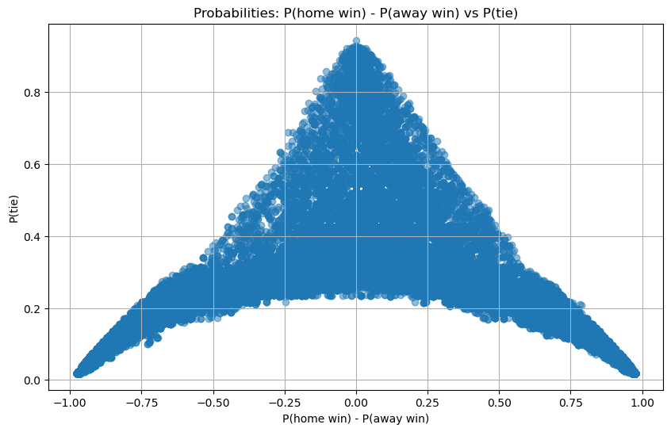

```python
filled_data['P_home_win_minus_away_win'] = filled_data['P_home_win_norm'] - filled_data['P_away_win_norm']

plt.figure(figsize=(10, 6))
plt.scatter(filled_data['P_home_win_minus_away_win'], filled_data['P_tie_norm'], alpha=0.5, label="Probabilities")
plt.xlabel('P(home win) - P(away win)')
plt.ylabel('P(tie)')
plt.title('Probabilities: P(home win) - P(away win) vs P(tie)')
plt.grid(True)
plt.show()
```